# Government Agencies × Private Data Providers: A Two-Mode Network

Federal contract awards from USAspending.gov

Leja Ejury

November 09, 2026

## 1. What this graph shows

A **two-mode (bipartite) network** has two kinds of nodes, and edges only run *between* the kinds, never within them:

- **Mode 1: government**: the federal *awarding sub-agency* (e.g., ICE, FBI, Army).
- **Mode 2: companies**: private data, analytics, and information providers.
- **Edge**: at least one contract from that agency to that company in the period.

Each edge carries **two weights**, and the graph shows both:

| Weight | Encoded as | Why |
| --- | --- | --- |
| **Contract size** (total $ obligated) | **edge width** (log scale) | Dollar values span ~6 orders of magnitude; a linear width would make everything but the top edge invisible. |
| **Number of contracts** | **edge color** (light → dark) | Separates *one big contract* (thick, pale) from *many small, recurring ones* (thin, dark), which is a different kind of dependence. |

Node size = the node’s total contract dollars (its weighted degree, or “strength”).

## 2. Pull the data

The firms below are searched by **recipient name** in the USAspending Award Search API (contracts only: award types A–D). Edit `firm_queries` to add or remove companies. Results are cached to `CLAUDE/data/raw/usaspending_awards.csv` so knitting is fast after the first run.

```r
# search text -> clean firm label (regex used to map messy recipient names)
firm_queries <- tribble(
  ~query,              ~firm,                         ~pattern,
  "LexisNexis",        "RELX / LexisNexis",           "LEXISNEXIS|LEXIS-NEXIS|LEXIS NEXIS",
  "RELX",              "RELX / LexisNexis",           "^RELX|REED ELSEVIER",
  "Thomson Reuters",   "Thomson Reuters (West/CLEAR)","THOMSON REUTERS",
  "West Publishing",   "Thomson Reuters (West/CLEAR)","WEST PUBLISHING",
  "Palantir",          "Palantir",                    "PALANTIR",
  "Babel Street",      "Babel Street",                "BABEL STREET",
  "TransUnion",        "TransUnion",                  "TRANSUNION|TRANS UNION",
  "Equifax",           "Equifax",                     "EQUIFAX",
  "Experian",          "Experian",                    "EXPERIAN",
  "Clearview AI",      "Clearview AI",                "CLEARVIEW AI",
  "Venntel",           "Venntel",                     "VENNTEL",
  "Acxiom",            "Acxiom",                      "ACXIOM",
  "Penlink",           "Penlink",                     "PEN-LINK|PENLINK",
  "ShadowDragon",      "ShadowDragon",                "SHADOWDRAGON|SHADOW DRAGON",
  "Cobwebs",           "Cobwebs",                     "COBWEBS"
)
```

```r
fetch_recipient <- function(query, start, end) {
  out <- list(); page <- 1
  repeat {
    body <- list(
      filters = list(
        recipient_search_text = list(query),
        award_type_codes = list("A", "B", "C", "D"),
        time_period = list(list(start_date = start, end_date = end))
      ),
      fields = list("Award ID", "Recipient Name", "Awarding Agency",
                    "Awarding Sub Agency", "Award Amount", "Start Date",
                    "Description"),
      limit = 100, page = page, sort = "Award Amount", order = "desc"
    )
    resp <- request("https://api.usaspending.gov/api/v2/search/spending_by_award/") |>
      req_body_json(body, auto_unbox = TRUE) |>
      req_retry(max_tries = 4) |>
      req_perform() |>
      resp_body_json(simplifyVector = TRUE)
    if (length(resp$results) == 0) break
    out[[page]] <- as_tibble(resp$results)
    if (!isTRUE(resp$page_metadata$hasNext)) break
    page <- page + 1
    Sys.sleep(0.2)   # be polite to the API
  }
  bind_rows(out) |> mutate(query = query)
}

if (params$refresh || !file.exists(cache_file)) {
  raw <- lapply(firm_queries$query, fetch_recipient,
                start = params$start_date, end = params$end_date) |>
    bind_rows()
  write.csv(raw, cache_file, row.names = FALSE)
} else {
  raw <- read.csv(cache_file, check.names = FALSE) |> as_tibble()
}
nrow(raw)
```

```
## [1] 7579
```

## 3. Clean and build the edge list

Different searches can return the same award, and a search can pick up unrelated companies (e.g., “Clearview” matches more than Clearview AI), so each recipient name is matched against the firm’s regex, and awards are de-duplicated.

```r
awards <- raw |>
  distinct(`Award ID`, `Recipient Name`, .keep_all = TRUE) |>
  mutate(recipient = toupper(`Recipient Name`))

# assign each award to the first firm whose pattern matches its recipient name
awards$firm <- NA_character_
for (i in seq_len(nrow(firm_queries))) {
  hit <- is.na(awards$firm) & grepl(firm_queries$pattern[i], awards$recipient)
  awards$firm[hit] <- firm_queries$firm[i]
}

awards <- awards |>
  filter(!is.na(firm), `Award Amount` > 0) |>
  mutate(agency     = `Awarding Agency`,
         sub_agency = `Awarding Sub Agency`,
         amount     = `Award Amount`,
         start      = as.Date(`Start Date`))

# Which raw recipient names were kept? (check for false matches here)
awards |> count(firm, recipient, sort = TRUE)
```

| firm | recipient | n |
| --- | --- | --- |
| Thomson Reuters (West/CLEAR) | WEST PUBLISHING CORPORATION | 2861 |
| RELX / LexisNexis | RELX INC. | 2232 |
| Experian | EXPERIAN INFORMATION SOLUTIONS, INC. | 292 |
| RELX / LexisNexis | LEXISNEXIS SPECIAL SERVICES INC | 188 |
| Equifax | EQUIFAX INFORMATION SERVICES LLC | 183 |
| Palantir | PALANTIR TECHNOLOGIES INC. | 177 |
| Equifax | EQUIFAX WORKFORCE SOLUTIONS LLC | 159 |
| Thomson Reuters (West/CLEAR) | THOMSON REUTERS (MARKETS) LLC | 120 |
| RELX / LexisNexis | LEXISNEXIS RISK SOLUTIONS FL INC. | 104 |
| TransUnion | TRANSUNION RISK AND ALTERNATIVE DATA SOLUTIONS, INC. | 79 |

[output cut: 29 more lines]

```r
# keep the top N sub-agencies by spending so the graph stays legible
top_subs <- awards |>
  group_by(sub_agency) |>
  summarise(total = sum(amount)) |>
  slice_max(total, n = params$top_agencies) |>
  pull(sub_agency)

edges <- awards |>
  filter(sub_agency %in% top_subs) |>
  group_by(from = sub_agency, to = firm) |>
  summarise(n_contracts = n(),
            total_amount = sum(amount),
            parent_agency = first(agency),
            .groups = "drop")

nodes <- bind_rows(
  edges |> group_by(name = from) |>
    summarise(strength = sum(total_amount), parent = first(parent_agency)) |>
    mutate(type = "Government agency"),
  edges |> group_by(name = to) |>
    summarise(strength = sum(total_amount)) |>
    mutate(type = "Company", parent = name)
)

g <- tbl_graph(nodes = nodes, edges = edges, directed = FALSE)
cat(sum(nodes$type == "Government agency"), "agencies,",
    sum(nodes$type == "Company"), "companies,",
    nrow(edges), "edges,",
    dollar(sum(edges$total_amount), scale = 1e-6, suffix = "M"), "total\n")
```

```
## 25 agencies, 12 companies, 131 edges, $5,257.20M total
```

```r
# shared encodings so every plot reads the same way
fmt_dollars <- label_dollar(scale_cut = cut_short_scale())

edge_scales <- list(
  scale_edge_width_continuous(
    name = "Contract size\n(total $, log scale)",
    range = c(0.15, 2.8), trans = "log10", labels = fmt_dollars),
  scale_edge_colour_gradient(
    name = "Number of\ncontracts",
    low = edge_low, high = edge_high, trans = "log10",
    breaks = c(1, 3, 10, 30, 100, 300))
)
node_scales <- list(
  scale_fill_manual(name = NULL,
                    values = c("Government agency" = col_agency, "Company" = col_firm)),
  scale_shape_manual(name = NULL,
                     values = c("Government agency" = 22, "Company" = 21)),
  scale_size_area(name = "Node total $", max_size = 10, labels = fmt_dollars,
                  breaks = c(1e8, 5e8, 2e9))
)
node_guides <- guides(
  fill  = guide_legend(order = 1, override.aes = list(size = 5)),
  shape = guide_legend(order = 1, override.aes = list(size = 5)),
  size  = guide_legend(order = 2, override.aes = list(shape = 21, fill = "#8a8984", colour = "white")))
net_theme <- theme_void(base_size = 11) +
  theme(legend.position = "right",
        plot.title = element_text(face = "bold", size = 14),
        plot.subtitle = element_text(colour = "#52514e"),
        plot.margin = margin(10, 10, 10, 10))
```

## 4. Bipartite layout: government on the left, companies on the right

This is the most literal picture of a two-mode graph. Agencies are grouped by parent department; companies are placed at the average height of the agencies they contract with, which keeps crossings down.

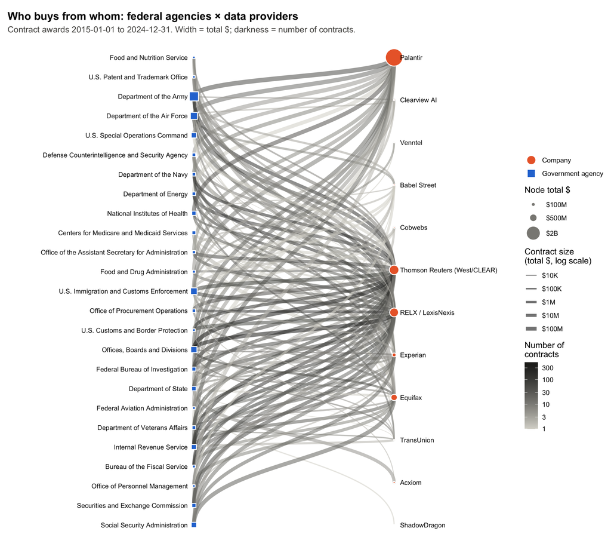

```r
# y positions: agencies sorted by department then spending
agency_order <- nodes |>
  filter(type == "Government agency") |>
  arrange(parent, desc(strength)) |>
  mutate(y = rev(seq_len(n())))

# companies: weighted barycenter of their agencies' heights
firm_y <- edges |>
  left_join(agency_order |> select(from = name, y), by = "from") |>
  group_by(name = to) |>
  summarise(bary = weighted.mean(y, total_amount)) |>
  arrange(bary) |>
  mutate(y = seq(min(agency_order$y), max(agency_order$y), length.out = n()))

lay <- nodes |>
  left_join(bind_rows(agency_order |> select(name, y),
                      firm_y |> select(name, y)), by = "name") |>
  mutate(x = ifelse(type == "Government agency", 0, 1))

ggraph(g, layout = "manual", x = lay$x, y = lay$y) +
  geom_edge_diagonal(aes(edge_width = total_amount, edge_colour = n_contracts),
                     alpha = 0.55, lineend = "round") +
  geom_node_point(aes(fill = type, shape = type, size = strength),
                  colour = "white", stroke = 0.8) +
  geom_node_text(aes(label = name,
                     hjust = ifelse(type == "Company", 0, 1),
                     x = x + ifelse(type == "Company", 0.03, -0.03)),
                 size = 3, colour = "#0b0b0b") +
  edge_scales + node_scales +
  scale_x_continuous(expand = expansion(add = c(0.9, 0.6))) +
  node_guides +
  labs(title = "Who buys from whom: federal agencies × data providers",
       subtitle = sprintf("Contract awards %s to %s. Width = total $; darkness = number of contracts.",
                          params$start_date, params$end_date)) +
  net_theme
```

## 5. Force-directed layout: clusters and brokers

The same graph laid out by network structure. Companies that sit between many agencies (high-degree “hubs”) pull to the center; agencies that rely on a single provider sit on the edge.

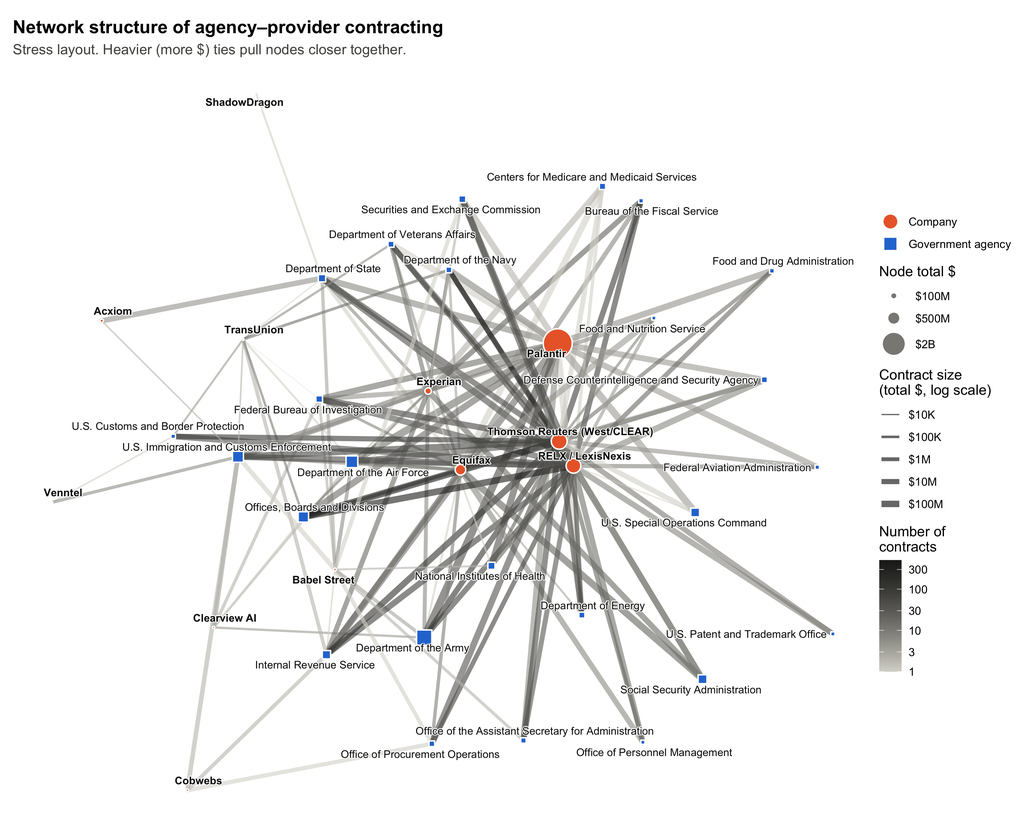

```r
set.seed(431)
ggraph(g, layout = "stress", weights = 1 / log10(total_amount)) +
  geom_edge_link(aes(edge_width = total_amount, edge_colour = n_contracts),
                 alpha = 0.6, lineend = "round") +
  geom_node_point(aes(fill = type, shape = type, size = strength),
                  colour = "white", stroke = 0.8) +
  geom_node_text(aes(label = name,
                     fontface = ifelse(type == "Company", "bold", "plain")),
                 repel = TRUE, size = 2.9, colour = "#0b0b0b",
                 max.overlaps = 30, bg.colour = "white", bg.r = 0.1) +
  edge_scales + node_scales +
  node_guides +
  labs(title = "Network structure of agency–provider contracting",
       subtitle = "Stress layout. Heavier (more $) ties pull nodes closer together.") +
  net_theme
```

## 6. The same graph as a matrix (read exact values)

A two-mode network *is* a matrix, agencies × companies. This view shows both weights precisely: **fill = contract dollars**, **number in cell = number of contracts**. Use it alongside the graph in the paper when readers need exact values.

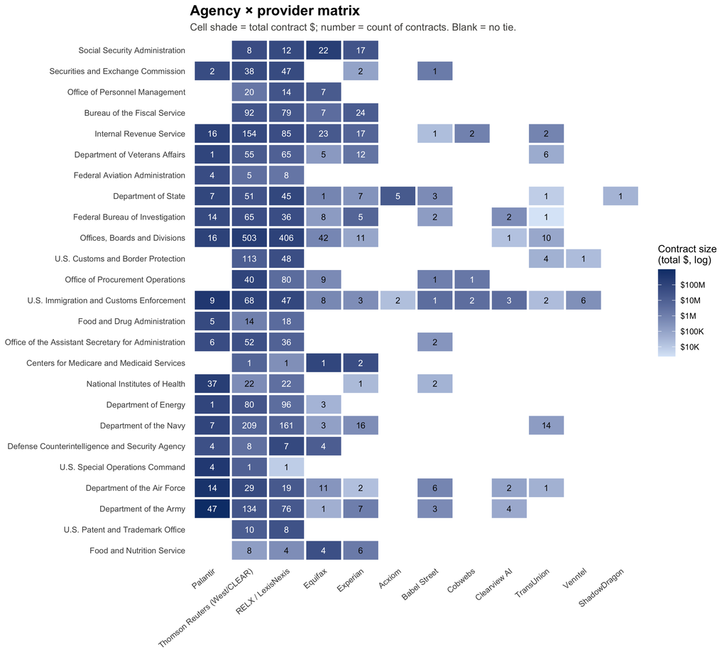

```r
mat <- edges |>
  mutate(from = factor(from, levels = agency_order$name),
         to   = factor(to, levels = nodes |> filter(type == "Company") |>
                          arrange(desc(strength)) |> pull(name)))

ggplot(mat, aes(x = to, y = from)) +
  geom_tile(aes(fill = total_amount), colour = "white", linewidth = 1) +
  geom_text(aes(label = n_contracts,
                colour = total_amount > 10^mean(log10(range(total_amount)))),
            size = 3, show.legend = FALSE) +
  scale_fill_gradient(name = "Contract size\n(total $, log)",
                      low = "#dbe8f8", high = "#0d3d78",
                      trans = "log10", labels = fmt_dollars) +
  scale_colour_manual(values = c(`TRUE` = "white", `FALSE` = "#0b0b0b")) +
  labs(x = NULL, y = NULL,
       title = "Agency × provider matrix",
       subtitle = "Cell shade = total contract $; number = count of contracts. Blank = no tie.") +
  theme_minimal(base_size = 10) +
  theme(axis.text.x = element_text(angle = 40, hjust = 1, vjust = 1),
        panel.grid = element_blank(),
        plot.title = element_text(face = "bold", size = 14),
        plot.subtitle = element_text(colour = "#52514e"))
```

## 7. Before, during, and after a crisis

Your research question is about change across a crisis, so here is the network split into three windows around COVID-19. Edit `periods` to use other crises (e.g., FEMA declaration windows). Node positions are fixed across panels so you can compare which ties appear, thicken, or disappear.

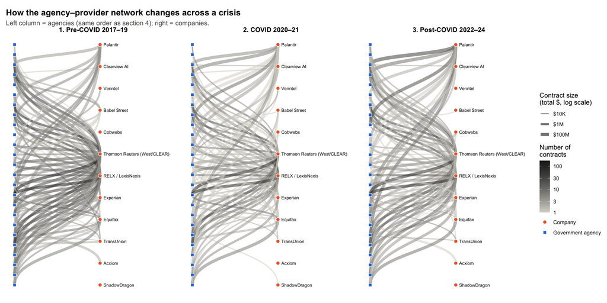

```r
periods <- tribble(
  ~period,                 ~from_date,   ~to_date,
  "1. Pre-COVID 2017–19",  "2017-01-01", "2019-12-31",
  "2. COVID 2020–21",      "2020-01-01", "2021-12-31",
  "3. Post-COVID 2022–24", "2022-01-01", "2024-12-31"
) |> mutate(across(c(from_date, to_date), as.Date))

edges_p <- awards |>
  filter(sub_agency %in% top_subs) |>
  cross_join(periods) |>
  filter(start >= from_date, start <= to_date) |>
  group_by(period, from = sub_agency, to = firm) |>
  summarise(n_contracts = n(), total_amount = sum(amount), .groups = "drop")

# one graph holding every period's edges; facet_edges splits them
g_p <- tbl_graph(nodes = nodes, edges = edges_p, directed = FALSE)

ggraph(g_p, layout = "manual", x = lay$x, y = lay$y) +
  geom_edge_diagonal(aes(edge_width = total_amount, edge_colour = n_contracts),
                     alpha = 0.55) +
  geom_node_point(aes(fill = type, shape = type), size = 2.5, colour = "white") +
  geom_node_text(aes(label = ifelse(type == "Company", name, "")),
                 hjust = 0, nudge_x = 0.04, size = 2.6) +
  facet_edges(~period) +
  edge_scales + node_scales[1:2] +
  scale_x_continuous(expand = expansion(add = c(0.1, 0.9))) +
  labs(title = "How the agency–provider network changes across a crisis",
       subtitle = "Left column = agencies (same order as section 4); right = companies.") +
  net_theme + theme(strip.text = element_text(face = "bold", size = 11))
```

```r
edges_p |>
  group_by(period) |>
  summarise(ties = n(),
            contracts = sum(n_contracts),
            total = dollar(sum(total_amount), scale = 1e-6, suffix = "M"),
            agencies = n_distinct(from),
            firms = n_distinct(to))
```

| period | ties | contracts | total | agencies | firms |
| --- | --- | --- | --- | --- | --- |
| 1. Pre-COVID 2017–19 | 93 | 1075 | $858.96M | 24 | 10 |
| 2. COVID 2020–21 | 87 | 515 | $1,084.62M | 24 | 11 |
| 3. Post-COVID 2022–24 | 83 | 635 | $2,125.82M | 23 | 10 |

## 8. Network statistics

```r
ig <- as.igraph(g)
V(ig)$type <- V(ig)$type == "Company"   # igraph's bipartite flag

node_stats <- tibble(
  name = V(ig)$name,
  mode = ifelse(V(ig)$type, "Company", "Agency"),
  degree = degree(ig),
  total_dollars = strength(ig, weights = E(ig)$total_amount),
  total_contracts = strength(ig, weights = E(ig)$n_contracts)
) |>
  arrange(mode, desc(total_dollars)) |>
  mutate(total_dollars = dollar(total_dollars, scale = 1e-6, suffix = "M", accuracy = 0.1))

node_stats
```

| name | mode | degree | total_dollars | total_contracts |
| --- | --- | --- | --- | --- |
| Department of the Army | Agency | 7 | $1,036.1M | 272 |
| Department of the Air Force | Agency | 8 | $579.0M | 84 |
| U.S. Immigration and Customs Enforcement | Agency | 11 | $499.7M | 151 |
| Offices, Boards and Divisions | Agency | 7 | $438.2M | 989 |
| Social Security Administration | Agency | 4 | $305.1M | 59 |
| U.S. Special Operations Command | Agency | 3 | $295.1M | 6 |
| Internal Revenue Service | Agency | 8 | $263.2M | 300 |
| Department of State | Agency | 9 | $199.3M | 121 |
| National Institutes of Health | Agency | 5 | $180.0M | 84 |
| Securities and Exchange Commission | Agency | 5 | $165.4M | 90 |

[output cut: 27 more lines]

```r
# one-mode projection: companies linked when they share an agency client
proj <- bipartite_projection(ig, which = "true")
cat("Company–company density (shared agency clients):",
    round(edge_density(proj), 2), "\n")
```

```
## Company–company density (shared agency clients): 0.95
```

```r
edges |>
  arrange(desc(total_amount)) |>
  mutate(total_amount = dollar(total_amount)) |>
  select(agency = from, company = to, n_contracts, total_amount) |>
  head(20)
```

| agency | company | n_contracts | total_amount |
| --- | --- | --- | --- |
| Department of the Army | Palantir | 47 | $994,446,381 |
| Department of the Air Force | Palantir | 14 | $503,605,821 |
| U.S. Immigration and Customs Enforcement | Palantir | 9 | $311,232,336 |
| U.S. Special Operations Command | Palantir | 4 | $286,073,147 |
| Offices, Boards and Divisions | Thomson Reuters (West/CLEAR) | 503 | $197,310,086 |
| National Institutes of Health | Palantir | 37 | $176,541,055 |
| Social Security Administration | Equifax | 22 | $175,216,712 |
| Internal Revenue Service | Palantir | 16 | $129,576,524 |
| Offices, Boards and Divisions | RELX / LexisNexis | 406 | $121,964,601 |
| Offices, Boards and Divisions | Palantir | 16 | $118,105,592 |

[output cut: 10 more lines]

## 9. Caveats to note in the paper

- **Data purchases vs. other services.** RELX (which also owns Elsevier) and Thomson Reuters (Westlaw) contracts include legal research and journal subscriptions as well as person-search products (Accurint, CLEAR). Use the `Description` field, or product/service codes, to separate them, as your proposal anticipates.
- **Recipient search is name-based.** Check the recipient table in section 3 for false matches before interpreting a tie.
- **Award Amount** is the total obligated over the award’s life, dated by the award’s start date; multi-year contracts are assigned to the year they began.
- **Sub-agency cut-off.** Only the top 25 sub-agencies by spending are drawn; change `top_agencies` in the YAML header.